# Economic analysis of femoral stem fixation method in a US Medicare population with hip fracture

The goal of this analysis is to replicate the results from Blythe et al (2020): Fixation method for hip stems following femoral neck fracture, but in a US-based Medicare population. The three age groups will be similar to the original study but bounded by Medicare inclusion: 65-74, 75-84, and 85+. Data will be comprised of US-based registry data for transition probabilities (revision, mortality) and costs where possible. Where new data is unobtainable, we will use values from the literature. The analysis is shown below.

```r
options(scipen = 100, digits = 5)
library(EnvStats)
library(LaplacesDemon)
library(patchwork)
library(knitr)
library(tidyverse)

# Model inputs
iter <- 50000 # define number of iterations
discount <- 0.03 # define discount rate
WTP <- 100000 # US WTP threshold
```

The basic structure of this population-based model is as follows:  
1. Obtain the basic prevalence of each group: HA vs THA, cemented vs cementless, and by age, for 12 groups in total. All patients in this model are assumed to be receiving their new hips following a femoral neck fracture.  
2. Assume that each group enters the model at time 0, or when they first receive the prosthesis, and are assigned a cost for the procedure.  
3. Each group then proceeds through a 5 year span, iterating by year, with the costs and utilities of stable states, revisions and dislocations varying by year. The stable population in each year corresponds to the surviving population who has not undergone a revision surgery or closed reduction of dislocation.  
4. The differences between the baseline population and a default strategy of cementing or not cementing for each age group will be calculated by assuming that all patients receive a particular fixation type for femoral stem, rather than using the existing prevalence of each procedure.

```r
# Call parameters and functions required to populate models
set.seed(888) # repeatability
source("./0_Parameters_US.R")
source("./1_Model_function.R")

# Run models for each age group and merge them together into one long dataframe
source("./2_Age_65_74.R")
source("./3_Age_75_84.R")
source("./4_Age_85_plus.R")

models <- rbind(
  model_65_74,
  model_75_84,
  model_85_plus
)

kable(head(models), format.args = list(big.mark = ","), caption = "Extract of simulation model results")
```

Extract of simulation model results

| Costs | QALYs | Strategy | Prosthesis | Age |
| --- | --- | --- | --- | --- |
| -1,203,546 | 557.13 | All patients receive cemented fixation | Hemiarthroplasty | 65 to 74 |
| 433,158 | 209.10 | All patients receive cemented fixation | Hemiarthroplasty | 65 to 74 |
| -4,515,629 | 195.48 | All patients receive cemented fixation | Hemiarthroplasty | 65 to 74 |
| -3,558,006 | 320.88 | All patients receive cemented fixation | Hemiarthroplasty | 65 to 74 |
| -5,296,027 | 111.97 | All patients receive cemented fixation | Hemiarthroplasty | 65 to 74 |
| -3,557,876 | 197.18 | All patients receive cemented fixation | Hemiarthroplasty | 65 to 74 |

```r
# Analysis summary
analysis <- models |>
  group_by(Strategy, Prosthesis, Age) |>
  summarise(
    Total_Cost_5y = mean(Costs),
    Total_Cost_5y_low = quantile(Costs, 0.025),
    Total_Cost_5y_high = quantile(Costs, 0.975),
    Total_QALY_5y = mean(QALYs),
    Total_QALY_5y_low = quantile(QALYs, 0.025),
    Total_QALY_5y_high = quantile(QALYs, 0.975),
    Pct_Cost_Saving = sum(Costs < 0) / iter,
    Pct_QALY_Gaining = sum(QALYs > 0) / iter,
    NMB = sum(mean(QALYs) * WTP - mean(Costs)),
    Pct_Cost_Effective = sum((QALYs * WTP - Costs) > 0) / iter
  ) |>
  mutate(Total_Cost_5y = Total_Cost_5y * (1 + discount)^5) # Convert $2019 to $2024
total <- analysis |>
  group_by(Strategy) |>
  summarise(
    Cost = sum(Total_Cost_5y),
    Cost_low = sum(Total_Cost_5y_low),
    Cost_high = sum(Total_Cost_5y_high),
    QALY = sum(Total_QALY_5y),
    QALY_low = sum(Total_QALY_5y_low),
    QALY_high = sum(Total_QALY_5y_high)
  )

with(
  subset(total, Strategy == "All patients receive cemented fixation"),
  print(paste0(
    "The overall annual savings to Medicare of switching to cemented fixation are $",
    ceiling(sum(Cost)), " ($", ceiling(sum(Cost_low)), ", $", ceiling(sum(Cost_high)), ")",
    " and ",
    ceiling(sum(QALY)), " (", ceiling(sum(QALY_low)), ", ", ceiling(sum(QALY_high)), ")",
    " QALYs."
  ))
)
```

```
## [1] "The overall annual savings to Medicare of switching to cemented fixation are $-15973120 ($-38181218, $6228049) and 1550 (-374, 3490) QALYs."
```

```r
kable(analysis, format.args = list(big.mark = ","), caption = "Simulation results")
```

Simulation results

| Strategy | Prosthesis | Age | Total_Cost_5y | Total_Cost_5y_low | Total_Cost_5y_high | Total_QALY_5y | Total_QALY_5y_low | Total_QALY_5y_high | Pct_Cost_Saving | Pct_QALY_Gaining | NMB | Pct_Cost_Effective |
| --- | --- | --- | --- | --- | --- | --- | --- | --- | --- | --- | --- | --- |
| All patients receive cemented fixation | Hemiarthroplasty | 65 to 74 | -2,978,664 | -6,828,147 | 970,690 | 308.52360 | -88.5234 | 708.1736 | 0.93024 | 0.93624 | 33,421,782 | 0.94780 |
| All patients receive cemented fixation | Hemiarthroplasty | 75 to 84 | -5,461,037 | -12,641,552 | 1,912,862 | 557.42625 | -164.9704 | 1,282.9550 | 0.92644 | 0.93464 | 60,453,364 | 0.94668 |
| All patients receive cemented fixation | Hemiarthroplasty | 85 and over | -5,404,311 | -12,854,462 | 2,188,243 | 551.59050 | -167.5622 | 1,272.6380 | 0.91690 | 0.93306 | 59,820,856 | 0.94532 |
| All patients receive cemented fixation | Total hip arthroplasty | 65 to 74 | -1,058,526 | -2,888,206 | 545,737 | 64.45574 | 21.3112 | 111.3951 | 0.87194 | 0.99834 | 7,358,668 | 0.99790 |
| All patients receive cemented fixation | Total hip arthroplasty | 75 to 84 | -786,185 | -2,168,925 | 436,421 | 47.62002 | 16.0673 | 82.0679 | 0.86390 | 0.99858 | 5,440,172 | 0.99816 |
| All patients receive cemented fixation | Total hip arthroplasty | 85 and over | -284,397 | -799,927 | 174,096 | 20.02597 | 8.7277 | 32.4039 | 0.85346 | 0.99980 | 2,247,921 | 0.99970 |
| All patients receive cementless fixation | Hemiarthroplasty | 65 to 74 | 1,730,465 | -660,585 | 4,061,072 | -180.26942 | -423.5677 | 61.7641 | 0.07836 | 0.07254 | -19,519,657 | 0.05942 |
| All patients receive cementless fixation | Hemiarthroplasty | 75 to 84 | 4,295,885 | -1,618,567 | 10,064,680 | -440.07183 | -1,025.8225 | 142.7978 | 0.07770 | 0.06978 | -47,712,852 | 0.05712 |
| All patients receive cementless fixation | Hemiarthroplasty | 85 and over | 5,793,620 | -2,507,500 | 13,942,454 | -595.75404 | -1,387.9664 | 194.3801 | 0.08760 | 0.06986 | -64,573,031 | 0.05764 |
| All patients receive cementless fixation | Total hip arthroplasty | 65 to 74 | 77,981 | -193,654 | 394,842 | -2.68972 | -11.2023 | 5.3098 | 0.33866 | 0.26226 | -336,240 | 0.25248 |
| All patients receive cementless fixation | Total hip arthroplasty | 75 to 84 | 99,046 | -212,779 | 458,010 | -5.15598 | -14.3408 | 3.4093 | 0.31826 | 0.12358 | -601,036 | 0.12824 |
| All patients receive cementless fixation | Total hip arthroplasty | 85 and over | 13,785 | -222,724 | 287,926 | -0.13143 | -6.6811 | 5.9269 | 0.48416 | 0.49472 | -25,034 | 0.49090 |

```r
write.csv(analysis, "./full_model.csv")
```

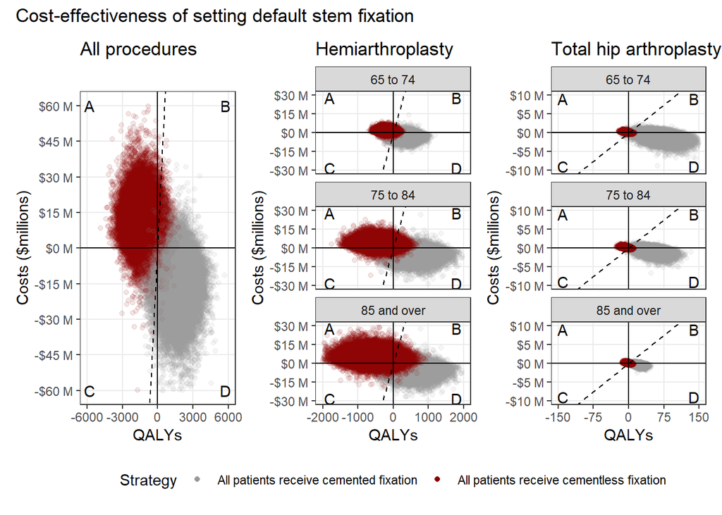

One of our primary motivations is to highlight the false economy of saving 7 minutes for a primary procedure. In our all hips are cemented scenario, this is how that might look:

```
## [1] "Cementing requires an additional 769 (521, 1066)  hours per year (nationally) of operating theater time."
```

```
## [1] "Revision change over 5 years: -128 (-123, -134)"
```

```
## [1] "As a result of cementing, there would be an anticipated change of -168 (-310, 1) hours of physician time from avoiding closed reductions."
```

```
## [1] "This would be accompanied by an anticipated change of -6014 (-10760, 13) hours of ED time from avoiding dislocation-associated visits."
```